TATA TWITTER ANALYTICS

```r
#install.packages("rtweet")
library(rtweet)
library(dplyr)
library(tidyr)
#install.packages("tidytext",dependencies = TRUE)
library(tidytext)
```

```r
library(ggplot2)
#install.packages("qdap")
#install.packages("qdapRegex")
```

Topic Selection: We have selected “TATA” as our Brand for doing Twitter analytics. We extract tweets in English covering major TATA brands with retweets disabled. We also apply date and character format conversions as appropriate.

```r
library(rtweet)

setwd('C:/Users/Karthik/Documents/Lakshmi - Back up docs/Learning/Data Analytics/BABI/Sessions/S15/WSMA Assgn');

tweetTATA =search_tweets("#Tata OR #Tatadocomo OR #tata_comm OR #TataMotors OR #tatatrusts OR #TataCompanies OR #TataSky OR #TataAIA_Life OR #TCS OR #TataCLiQ OR #tata_housing OR #TATAAIGIndia OR #TataPower OR #Tatacapital#Tata OR #Tatadocomo OR #tata_comm OR #TataMotors OR #tatatrusts OR #TataCompanies OR #TataSky OR #TataAIA_Life OR #TCS OR #TataCLiQ OR #tata_housing OR #TATAAIGIndia OR #TataPower OR #Tatacapital",n=100000,lang='en',include_rts = F,retryonratelimit = F)

dim(tweetTATA)
```

```
## [1] 1266   90
```

```r
View(tweetTATA)

names(tweetTATA)
```

```
##  [1] "user_id"                 "status_id"
##  [3] "created_at"              "screen_name"
##  [5] "text"                    "source"
##  [7] "display_text_width"      "reply_to_status_id"
##  [9] "reply_to_user_id"        "reply_to_screen_name"
## [11] "is_quote"                "is_retweet"
## [13] "favorite_count"          "retweet_count"
## [15] "quote_count"             "reply_count"
## [17] "hashtags"                "symbols"
## [19] "urls_url"                "urls_t.co"
## [21] "urls_expanded_url"       "media_url"
## [23] "media_t.co"              "media_expanded_url"
## [25] "media_type"              "ext_media_url"
## [27] "ext_media_t.co"          "ext_media_expanded_url"
## [29] "ext_media_type"          "mentions_user_id"
```

[output cut: 30 more lines]

```r
saveRDS(tweetTATA, "tweet_tata.rds")

tweets_tata = readRDS("tweet_tata.rds")

library(dplyr)

library(lubridate)
tweetTATA$date <- date(tweetTATA$created_at)
tweetTATA$hour <- hour(tweetTATA$created_at)
tweetTATA$text <- as.character(tweetTATA$text)
#str(tweets_tata)
```

Exploratory Data Analysis

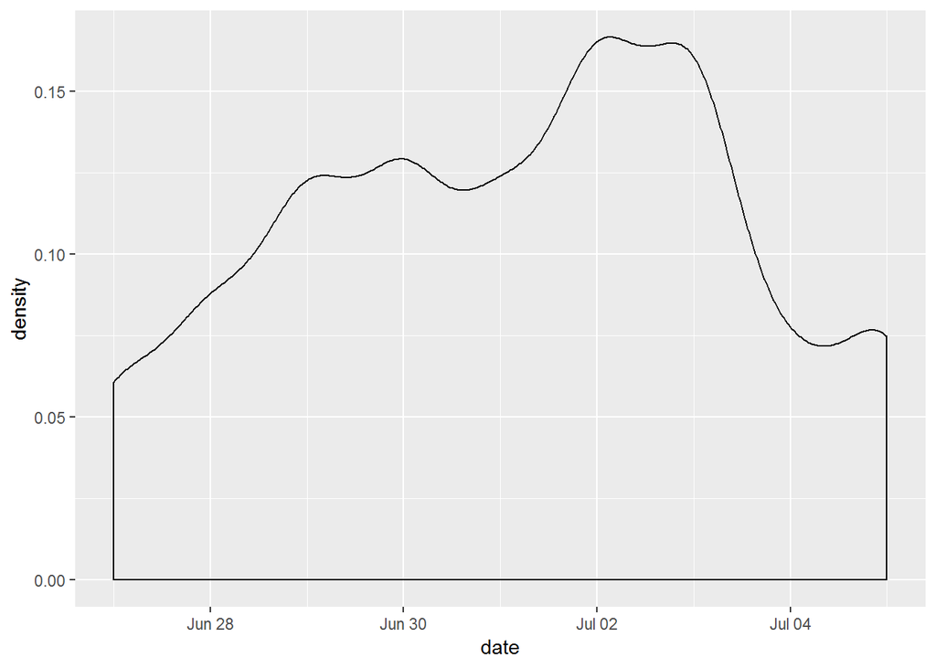

```r
library(ggplot2)

ggplot(tweetTATA, aes(x = date)) +
  geom_density()
```

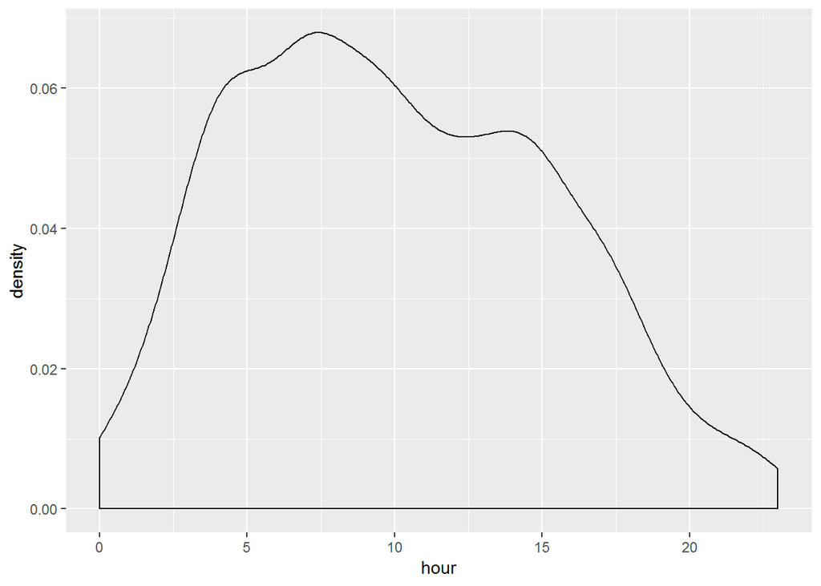

```r
ggplot(tweetTATA, aes(x = hour)) +
  geom_density()
```

```r
#Data Statistics
#Line counts
length(tweetTATA$text)
```

```
## [1] 1266
```

```r
#word count
library(stringi)
sum(stri_count_words(tweetTATA$text))
```

```
## [1] 35125
```

Data Cleaning We clean up the extract by removing numbers,punctuations,symbols, hyphens, and URLs. We also convert to lowercase. We follow this with the removal of standard stopwords and followed by custom stopwords where the words that come as part of the search tweets # tags are also removed. We kept this open so as to come back through an iterative process of analyzing the frequency and including more into the custom stopwords.

We then spot the pairs of words or bigrams that occur together.

```r
#install.packages("quanteda")
library(quanteda)
# Tokenize descriptions
tweettokens=tokens(tweets_tata$text,what="word",
                    remove_numbers=TRUE,
                    remove_punct=TRUE,
                    remove_symbols=TRUE,
                    split_hyphens=TRUE,
                    remove_url = T)


# Lowercase the tokens
tweettokens=tokens_tolower(tweettokens)


# remove stop words and unnecessary words
tweettokens=tokens_select(tweettokens, stopwords(),selection = "remove")
custom_stop <- c("tata","tcs","tatamotors","tatapower","tatasky","can", "amp", "one", "will", "just", "many", "new", "know", "also", "need", "may", "now", "rs",
                 "get", "s", "t", "m", "re", "via", "get", "k", "us","stayhome")

tweettokens=tokens_remove(tweettokens,custom_stop)

(n.tweet <- length(tweets_tata))
```

```
## [1] 90
```

```r
tweettokens2=tokens_ngrams(tweettokens,n=2)

# Creating a bag of words
tweettokensdfm=dfm(tweettokens2,tolower = FALSE)

#identify most freq bigrams
topfeatures(tweettokensdfm)
```

```
##                   gt_gt       #nifty_#banknifty           #tcs_#infosys
##                      30                      26                      26
##         #hdfc_#hdfcbank        #nifty50_#sensex         #nifty_#nifty50
##                      23                      22                      21
## #stockmarket_#stock2020         #nifty50_#nifty              #bse_#hdfc
##                      20                      19                      19
##          #hdfcbank_#sbi
##                      19
```

Inference: We see that the following pairs of words occur more frequently in the tweets.

We further spot words that occurs as sets of 3 or trigrams.

```r
#Create bi-grams
tweettokens3=tokens_ngrams(tweettokens,n=3)

# Creating a bag of words
tweettokensdfm3=dfm(tweettokens3,tolower = FALSE)

#identify most freq bigrams
topfeatures(tweettokensdfm3)
```

```
##               #bse_#hdfc_#hdfcbank               #hdfc_#hdfcbank_#sbi
##                                 19                                 19
##                #hdfcbank_#sbi_#tcs     #infosys_#icicibank_#kotakbank
##                                 19                                 19
##         #icicibank_#kotakbank_#itc               #kotakbank_#itc_#hul
##                                 19                                 19
##                    #itc_#hul_#fmcg                           gt_gt_gt
##                                 19                                 18
##                #jio_#ril_#reliance #ril_#reliance_#relianceindustries
##                                 16                                 16
```

Inference: We see competetitor oriented discussions in #jio_#ril_#reliance, #ril_#reliance_#relianceindustries and #itc_#hul_#fmcg where TATA has a presence, TATA Docomo and FMCG products of TATA being some examples.

#icicibank_#kotakbank_#itc#HUL including TATA - These firms are having high market capitalization

```r
library(qdapRegex)
twt_txt_url <- rm_twitter_url(tweets_tata$text)
twt_txt_chrs  <- gsub("[^A-Za-z0-9]", " ", twt_txt_url)
```

We create a corpus from the data

```r
library(tm)
```

```r
corpus<- Corpus(VectorSource(twt_txt_chrs))
corpus1<- Corpus(VectorSource(twt_txt_chrs))

writeLines(strwrap(corpus1[[100]]$content,50))
```

```
## Tata Salt Factory Busted Sold 10 thousand kg of
## Salt during Lockdown Tata Salt Lockdown Delhi
```

```r
writeLines(strwrap(corpus[[100]]$content,50))
```

```
## Tata Salt Factory Busted Sold 10 thousand kg of
## Salt during Lockdown Tata Salt Lockdown Delhi
```

Removal of Whitespace from the corpus

```r
#triming extra spaces
corpus_sp = tm_map(corpus, stripWhitespace)
```

```r
writeLines(strwrap(corpus_sp[[100]]$content,50))
```

```
## Tata Salt Factory Busted Sold 10 thousand kg of
## Salt during Lockdown Tata Salt Lockdown Delhi
```

Removal of User Names from the corpus

```r
#Remove User names
removeUsername <- function(x) gsub("@[^[:space:]]*", "", x)
corpus_un <- tm_map(corpus_sp, content_transformer(removeUsername))
```

```r
writeLines(strwrap(corpus_un[[100]]$content,50))
```

```
## Tata Salt Factory Busted Sold 10 thousand kg of
## Salt during Lockdown Tata Salt Lockdown Delhi
```

```r
corpus_lwr <- tm_map(corpus_un, tolower)
```

```r
writeLines(strwrap(corpus_lwr[[100]]$content,50))
```

```
## tata salt factory busted sold 10 thousand kg of
## salt during lockdown tata salt lockdown delhi
```

Removal of standard English stopwords and Custom Stopwords

```r
#stopword treatment
corpus_st = tm_map(corpus_lwr, removeWords, stopwords('english'))
```

```r
writeLines(strwrap(corpus_st[[100]]$content,50))
```

```
## tata salt factory busted sold 10 thousand kg salt
## lockdown tata salt lockdown delhi
```

```r
#Custom Stop words
# Create a vector of custom stop words
custom_stop <- c("tata","tcs","tatamotors","tatapower","tatasky","can", "amp", "one", "will", "just", "many", "new", "know", "also", "need", "may", "now", "rs",
                 "get", "s", "t", "m", "re", "via", "get", "k", "us","stayhome")

# Extract term frequency
#install.packages("qdap")


library(qdap)
#library(tm)
library(RWeka)
corpus_final <- tm_map(corpus_st, removeWords,custom_stop)
```

```r
writeLines(strwrap(corpus_final[[100]]$content,50))
```

```
## salt factory busted sold 10 thousand kg salt
## lockdown salt lockdown delhi
```

```r
removeSingle <- function(x) gsub(" . ", " ", x)
corpus_ref <- tm_map(corpus_final, content_transformer(removeSingle))
```

```r
## Warning in tm_map.SimpleCorpus(corpus, content_transformer(removeSingle)):
## transformation drops documents
writeLines(strwrap(corpus_ref[[100]]$content,50))
```

```
## salt factory busted sold 10 thousand kg salt
## lockdown salt lockdown delhi
```

```r
term_count_clean <- freq_terms(corpus_ref, 20)
term_count_clean
```

```
##    WORD        FREQ
## 1  nifty        233
## 2  bt           140
## 3  bts           90
## 4  india         89
## 5  tatacliq      87
## 6  buy           83
## 7  july          76
## 8  reliance      74
## 9  stock         72
## 10 stockmarket   72
## 11 today         64
## 12 banknifty     61
## 13 chimmy        58
## 14 service       57
## 15 good          55
## 16 hdfcbank      55
## 17 bill          54
## 18 companies     54
## 19 hdfc          52
## 20 infosys       51
```

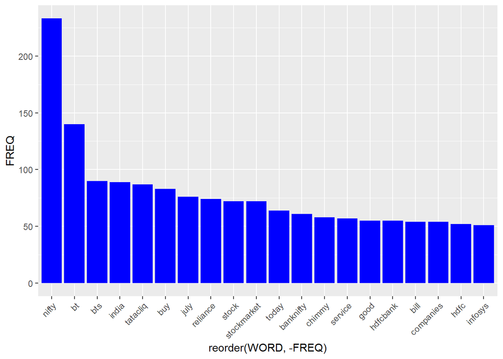

```r
# Create a bar plot of frequent terms
library(ggplot2)

# Create a subset dataframe
term50 <- subset(term_count_clean, FREQ > 30)

# Create a bar plot
ggplot(term50, aes(x = reorder(WORD,  -FREQ),  y = FREQ)) +
  geom_bar(stat = "identity", fill = "blue") +
  theme(axis.text.x = element_text(angle = 45, hjust = 1))
```

Most frequently used words - Inferences: NIFTY,Buy,Stock,stockmarket,Banknifty,trading - All refers to stock purchase and trading. bts,Chimmy -Tata (V), Shooky (Suga), Cooky (Jungkook), Koya (Rap Monster), Chimmy (Jimin), RJ (Jin), Mang (J-Hope). BTS band members cute keychain, a must have for all BTS fans. The characters were created by the BTS members themselves. India - As TATA is Indian based company,situation in India could be discussed about. Competitor companies like Reliance, Infosys are also much talked about. TATACliq - Due to COVID 19 situation,ecommerce industry has gained prominence. There are poor reviews with respect to TATACliq customer service which needs to be focussed upon. Service - Customer service is also major point of discussion

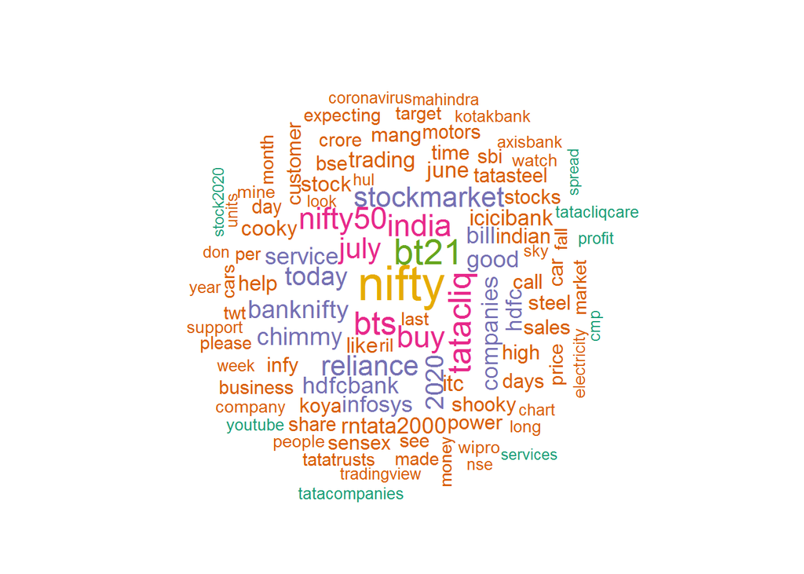

```r
# Create a word cloud based on min frequency
library(wordcloud)
#wordcloud(corpus_ref, min.freq = 200, colors = "red",
         # scale = c(5,0.5), random.order = FALSE)

# Create a colorful word cloud
library(RColorBrewer)
wordcloud(corpus_ref, max.words = 100,
          colors = brewer.pal(6,"Dark2"), scale = c(2.5,.5),
          random.order = FALSE)
```

```r
library(tm)


tdm<- TermDocumentMatrix(corpus, control= list(wordLengths= c(1, Inf)))

tdm
```

```
## <<TermDocumentMatrix (terms: 6786, documents: 1266)>>
## Non-/sparse entries: 29156/8561920
## Sparsity           : 100%
## Maximal term length: 40
## Weighting          : term frequency (tf)
```

```r
inspect(tdm)
```

```
## <<TermDocumentMatrix (terms: 6786, documents: 1266)>>
## Non-/sparse entries: 29156/8561920
## Sparsity           : 100%
## Maximal term length: 40
## Weighting          : term frequency (tf)
## Sample             :
##             Docs
## Terms        1156 1185 1235 130 306 318 321 362 647 792
##   a             1    2    1   0   0   0   2   0   0   2
##   and           0    0    0   0   0   0   1   0   0   1
##   for           0    1    0   1   1   0   0   0   0   0
##   in            0    3    0   2   2   2   0   1   0   0
##   of            1    0    0   0   1   0   0   0   0   1
##   tata          0    0    0   0   0   0   0   1   1   1
##   tatamotors    0    0    0   0   0   0   0   0   0   0
##   tcs           0    7    0   0   1   0   0   0   0   0
##   the           0    0    0   2   0   1   0   0   0   0
##   to            0    0    1   1   0   1   0   3   1   2
```

```r
inspect(tdm[1:10,1:7])
```

```
## <<TermDocumentMatrix (terms: 10, documents: 7)>>
## Non-/sparse entries: 14/56
## Sparsity           : 80%
## Maximal term length: 7
## Weighting          : term frequency (tf)
## Sample             :
##          Docs
## Terms     1 2 3 4 5 6 7
##   33      1 0 0 0 0 0 0
##   amp     1 1 0 0 0 0 0
##   at      1 0 0 0 0 0 1
##   be      1 0 0 0 1 0 0
##   bts     1 0 0 0 0 0 0
##   excited 1 0 0 0 0 0 0
##   first   1 0 0 0 0 0 0
##   have    1 1 0 0 0 0 0
##   i       1 0 0 0 0 0 0
##   in      1 0 0 0 0 0 0
```

Find the terms used most frequently

```r
library(ggplot2)
dtf <- DocumentTermMatrix(corpus)
freq.terms <- findFreqTerms(tdm, lowfreq = 25)
term.freq <- rowSums(as.matrix(tdm))
term.freq <- subset(term.freq, term.freq >25)
df <- data.frame(term = names(term.freq), freq= term.freq)
```

```r
(freq.terms <- findFreqTerms(tdm, lowfreq = 10))
```

```
##   [1] "amp"                 "at"                  "be"
##   [4] "bts"                 "first"               "have"
##   [7] "i"                   "in"                  "jungkook"
##  [10] "life"                "my"                  "off"
##  [13] "s"                   "so"                  "taehyung"
##  [16] "tata"                "the"                 "they"
##  [19] "this"                "time"                "twt"
##  [22] "will"                "2"                   "and"
##  [25] "companies"           "for"                 "is"
##  [28] "like"                "of"                  "people"
##  [31] "start"               "tcs"                 "to"
##  [34] "work"                "you"                 "a"
##  [37] "are"                 "business"            "cash"
##  [40] "covid"               "down"                "during"
##  [43] "hdfc"                "hdfcbank"            "job"
```

[output cut: 168 more lines]

```r
term.freq <- rowSums(as.matrix(tdm))
term.freq <- subset(term.freq, term.freq > 10)
df1 <- data.frame(term = names(term.freq), freq= term.freq)
(freq.terms <- findFreqTerms(tdm, lowfreq = 55))
```

```
##  [1] "amp"         "at"          "be"          "bts"         "have"
##  [6] "i"           "in"          "my"          "s"           "tata"
## [11] "the"         "they"        "this"        "will"        "2"
## [16] "and"         "for"         "is"          "of"          "tcs"
## [21] "to"          "you"         "a"           "are"         "hdfcbank"
## [26] "now"         "banknifty"   "nifty"       "reliance"    "has"
## [31] "nifty50"     "on"          "with"        "buy"         "july"
## [36] "tatamotors"  "bt21"        "but"         "chimmy"      "it"
## [41] "your"        "good"        "no"          "not"         "service"
## [46] "tatasky"     "more"        "or"          "today"       "india"
## [51] "by"          "all"         "can"         "t"           "rs"
## [56] "as"          "our"         "1"           "2020"        "from"
## [61] "that"        "we"          "tatapower"   "tatacliq"    "stockmarket"
## [66] "5"
```

```r
term.freq <- rowSums(as.matrix(tdm))
term.freq <- subset(term.freq, term.freq > 55)
df2 <- data.frame(term = names(term.freq), freq= term.freq)

(freq.terms <- findFreqTerms(tdm, lowfreq = 85))
```

```
##  [1] "amp"        "at"         "be"         "bts"        "have"
##  [6] "i"          "in"         "my"         "s"          "tata"
## [11] "the"        "this"       "2"          "and"        "for"
## [16] "is"         "of"         "tcs"        "to"         "you"
## [21] "a"          "are"        "nifty"      "on"         "with"
## [26] "tatamotors" "bt21"       "it"         "your"       "not"
## [31] "tatasky"    "india"      "by"         "as"         "from"
## [36] "we"         "tatapower"  "tatacliq"
```

```r
term.freq <- rowSums(as.matrix(tdm))
term.freq <- subset(term.freq, term.freq > 85)
df3 <- data.frame(term = names(term.freq), freq= term.freq)
```

[figure not shown]

```r
barplot(df2[1:10,]$freq~df3[1:10,]$term, las = 2, names.arg = df2[1:10,]$word,
        col ="lightblue", main ="Most frequent words",
        ylab = "Word frequencies", xlab = "Terms")
```

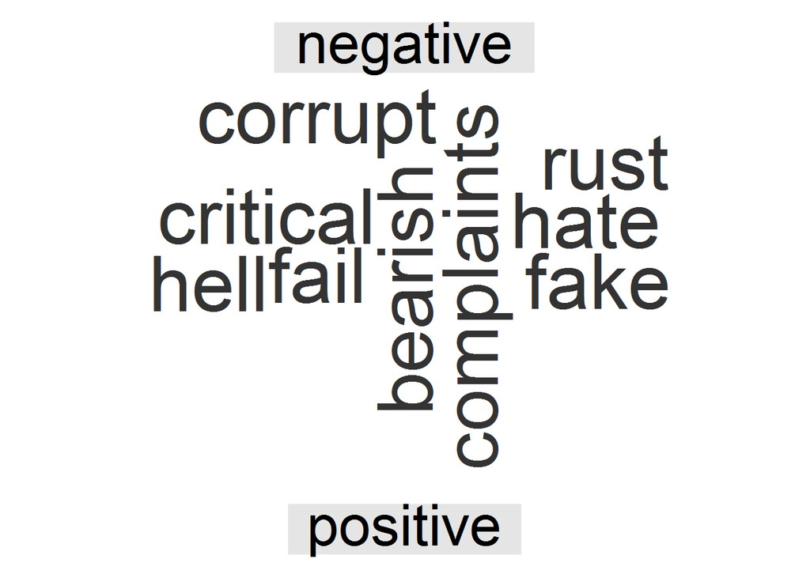

```r
library(wordcloud)
library(reshape2)
# take all the phrases
m <- as.matrix(tdm)
# calculate the frequency of words and sort it by frequency
word.freq <- sort(rowSums(m), decreasing = F)
docs1 <-tibble(phrases =names(word.freq))

# add an id, from 1 to n
docs1$ID <- row.names(docs1)

# split all the words
tidy_docs <- docs1 %>% unnest_tokens(word, phrases)

#create now the cloud: a pair of warnings, because you do not have negative words and it is joining by word(correct)
tidy_docs %>%
  inner_join(get_sentiments("bing")) %>%
  count(word, sentiment, sort = TRUE) %>%
  acast(word ~ sentiment, value.var = "n", fill = 0) %>%
  comparison.cloud(colors = c("gray20", "gray80"),
                   max.words = 25)
```

Inferences:

word association

```r
list1<- findAssocs(tdm, "means", 0.2)
corrdf1 <- t(data.frame(t(sapply(list1,c))))
corrdf1
```

```
##                  means
## boycotttatasky    0.45
## heck              0.45
## nonsense          0.45
## sqaure            0.45
## partnering        0.45
## regard            0.45
## requests          0.45
## stream            0.45
## tcsteam           0.45
## ist               0.45
## piwer             0.45
## ujits             0.45
## yearswhy          0.45
## easypaisa         0.45
## glad              0.45
## lodge             0.45
## nevertheless      0.45
## socialmedia       0.45
## telenorbankpk     0.45
## X200k             0.45
## babysit           0.45
## outsourcers       0.45
## skilled           0.45
## cesc              0.37
## h1b               0.34
## taking            0.33
## contacted         0.31
## X41               0.31
## faster            0.31
## datacabling       0.31
## member            0.31
## totalcontracting  0.31
## X89               0.31
## cognizant         0.31
## few               0.30
## recharge          0.26
## lost              0.26
## regular           0.26
## uk                0.26
## mean              0.26
## unit              0.26
## pic               0.26
## couriers          0.26
## immediately       0.26
## double            0.22
## took              0.22
## though            0.22
## construction      0.22
## X93               0.22
## saw               0.22
## anti              0.22
## looting           0.22
## twitter           0.22
## you               0.21
## do                0.21
## X40               0.20
```

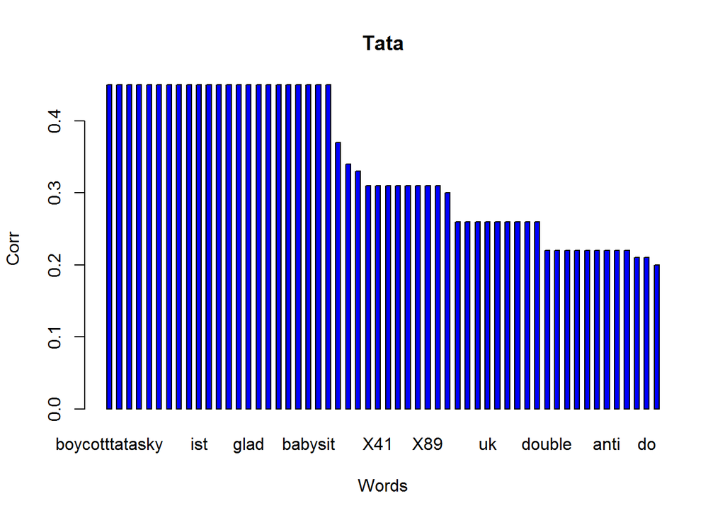

```r
barplot(t(as.matrix(corrdf1)), beside=TRUE,xlab = "Words",ylab = "Corr",col = "blue",main = "Tata",border = "black")
```

Inferences;

Clearly there is a huge displeasure with respect to the services rendered by Tatasky.

```r
list1<- findAssocs(tdm, "believe", 0.2)
corrdf1 <- t(data.frame(t(sapply(list1,c))))
corrdf1
```

```
##                        believe
## deaf                      0.58
## ear                       0.58
## natrajanchandrasekaran    0.58
## rajivsabharwal            0.58
## rbigovernor               0.58
## reducing                  0.58
## advised                   0.58
## autborised                0.58
## claim                     0.58
## distributor               0.58
## stands                    0.58
## blaming                   0.58
## consaff                   0.58
## empty                     0.58
## gonna                     0.58
## jagograhakjagoo           0.58
## complains                 0.41
## rbi                       0.41
## trust                     0.41
## roi                       0.41
## vikaspurohit              0.41
## tataaigindia              0.41
## existing                  0.33
## suggest                   0.33
## policy                    0.33
## receiving                 0.33
## feedback                  0.33
## however                   0.33
## continue                  0.29
## capital                   0.26
## following                 0.26
## goes                      0.26
## loan                      0.25
## use                       0.23
## box                       0.22
## ur                        0.20
```

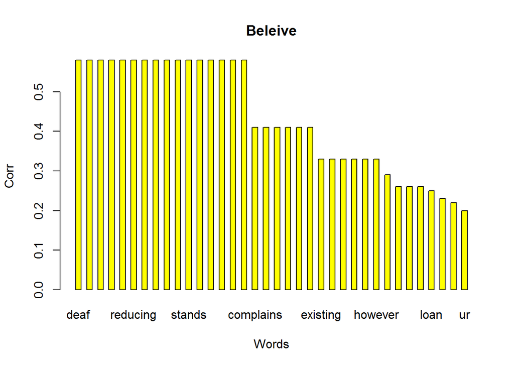

```r
barplot(t(as.matrix(corrdf1)), beside=TRUE,xlab = "Words",ylab = "Corr",col = "yellow",main = "Beleive",border = "black")
```

```r
list1<- findAssocs(tdm, "crazy", 0.2)
corrdf1 <- t(data.frame(t(sapply(list1,c))))
corrdf1
```

```
##       [,1]
## crazy Numeric,0
```

Dendogram:

```r
# remove sparse terms
tdm2 <- removeSparseTerms(tdm, sparse = 0.95)
m2 <- as.matrix(tdm2)
# cluster terms
distMatrix <- dist(scale(m2))
fit <- hclust(distMatrix, method = "ward")
```

```
## The "ward" method has been renamed to "ward.D"; note new "ward.D2"
```

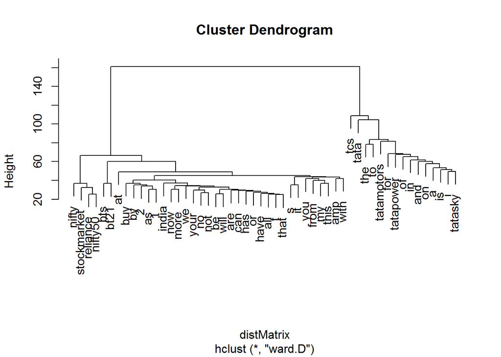

```r
plot(fit)
```

```r
#install.packages("syuzhet")
library(syuzhet)
```

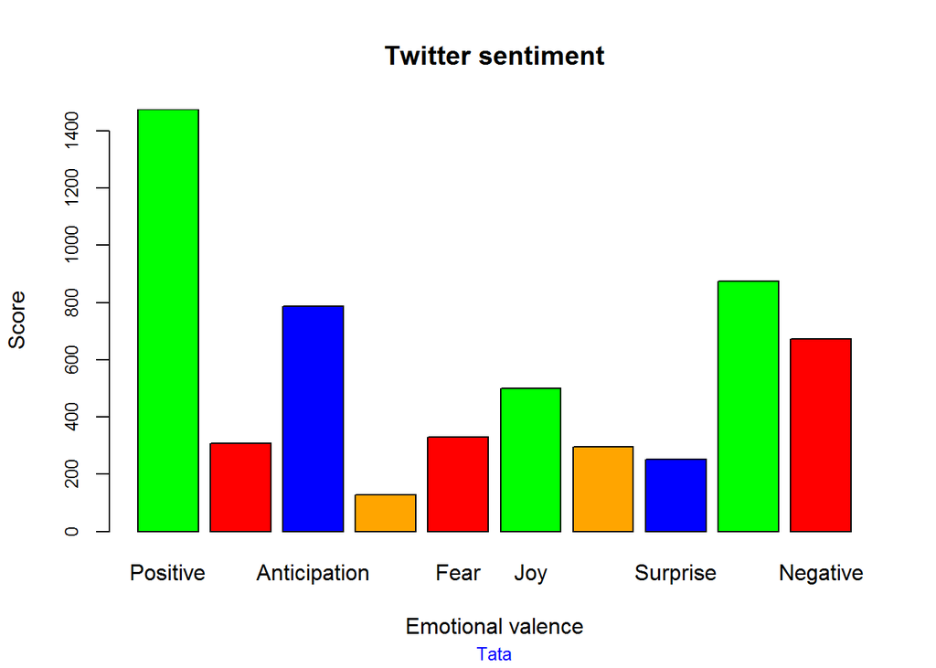

```r
mysentiment<-get_nrc_sentiment((tweets_tata$text))

# Get the sentiment score for each emotion
mysentiment.positive =sum(mysentiment$positive)
mysentiment.anger =sum(mysentiment$anger)
mysentiment.anticipation =sum(mysentiment$anticipation)
mysentiment.disgust =sum(mysentiment$disgust)
mysentiment.fear =sum(mysentiment$fear)
mysentiment.joy =sum(mysentiment$joy)
mysentiment.sadness =sum(mysentiment$sadness)
mysentiment.surprise =sum(mysentiment$surprise)
mysentiment.trust =sum(mysentiment$trust)
mysentiment.negative =sum(mysentiment$negative)

# Create the bar chart
yAxis <- c(mysentiment.positive,
           + mysentiment.anger,
           + mysentiment.anticipation,
           + mysentiment.disgust,
           + mysentiment.fear,
           + mysentiment.joy,
           + mysentiment.sadness,
           + mysentiment.surprise,
           + mysentiment.trust,
           + mysentiment.negative)

xAxis <- c("Positive","Anger","Anticipation","Disgust","Fear","Joy","Sadness",
           "Surprise","Trust","Negative")
colors <- c("green","red","blue","orange","red","green","orange","blue","green","red")
yRange <- range(0,yAxis)
barplot(yAxis, names.arg = xAxis,
        xlab = "Emotional valence", ylab = "Score", main = "Twitter sentiment",
        sub = "Tata", col = colors, border = "black", xpd = F, ylim = yRange,
        axisnames = T, cex.axis = 0.8, cex.sub = 0.8, col.sub = "blue")
```

Inferences:

Positive - Score is high reflecting that the customers are satisifed with TATA. Scoores of the below attributes also support the same. Trust Joy Anticipation Surprise

Negative - Customer dissatisfication with respect to ecommerce and TATASky services are to be noted which is impacting the brand value. Below attributes are signifying the same. Anger Disgust Fear Sadness